# The Classical Linear Regression Model

# Types of Data

- cross sectional data: the situation where the time is fixed and the observation changes. (company size and firm's perfomance, unemployment and growth) - linear relationship
- time series data: For time series data you fix the individual and you change the point in time at which you study the individual. (GDP over time)
- panel data (longitudinal data): a combination of crossectional and time series data - balanced & unbalanced panel data.
- big data: has less or no structure

** Detrending: Differencing: Subtracting the current value from the previous value (y(t)-y(t-1)) to remove linear trends.

** High frequency data: for which the intervals when the data is gathered are very small. (financial data)

# Notes

- Ramsey's (1969) RESET test to check whether the model is linear or not.

# Example

```python
import numpy as np
import pandas as pd
import matplotlib.pyplot as plt
from sklearn.linear_model import LinearRegression
```

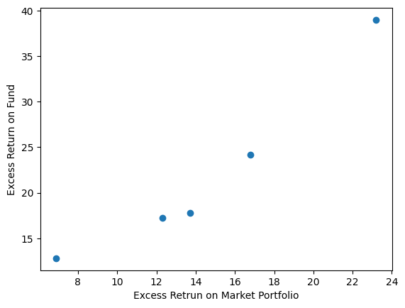

```python
month = list(np.arange(1,5))
excess_return = [17.8, 39.0, 12.8, 24.2, 17.2]
excess_return_market_index = [13.7, 23.2, 6.9, 16.8, 12.3]

plt.scatter(excess_return_market_index, excess_return)
plt.xlabel("Excess Retrun on Market Portfolio")
plt.ylabel("Excess Return on Fund")
plt.show();
```

```python
y = np.array(excess_return).reshape(-1, 1)
X = np.array(excess_return_market_index).reshape(-1, 1)


model = LinearRegression()
model.fit(X, y)

print(f"Intercept (alpha): {model.intercept_[0]:.2f}")
print(f"Slope (beta): {model.coef_[0][0]:.2f}")
```

```
Intercept (alpha): -1.74
Slope (beta): 1.64
```

# Using Adjusted $R^2$ to Decide Whether to Add a New Regressor

## Key Concepts

1. **Adjusted $R^2$:**
   - Adjusted $R^2$ accounts for the number of regressors in the model and adjusts $R^2$ by penalizing the addition of unnecessary predictors.
   - **Formula**: $$\text{Adjusted } R^2 = 1 - \left( \frac{(1 - R^2)(n - 1)}{n - k - 1} \right)$$ Where:
     - $R^2$: Coefficient of determination.
     - $n$: Number of observations.
     - $k$: Number of regressors (excluding the intercept).
2. **Purpose:**
   - Prevent overfitting by ensuring new regressors improve the model meaningfully.
   - Helps evaluate if the added variable provides significant explanatory power.

## When to Add a New Regressor

1. **Adjusted $R^2$ Increases**:
   - If adding a new regressor increases adjusted $R^2$, it suggests the new variable improves the model's explanatory power after accounting for the additional complexity.
   - **Action**: Add the regressor.
2. **Adjusted $R^2$ Decreases**:
   - If adding a new regressor decreases adjusted $R^2$, it suggests the variable does not provide meaningful additional information and adds unnecessary complexity.
   - **Action**: Do not add the regressor.
3. **Adjusted $R^2$ Remains Unchanged**:
   - If adjusted $R^2$ remains unchanged, the new variable is neutral and provides no substantial benefit.
   - **Action**: Consider excluding the regressor unless it has theoretical importance.

## Advantages of Using Adjusted $R^2$

- Penalizes models that add predictors without meaningful contribution.
- Protects against overfitting by focusing on the balance between goodness-of-fit and model complexity.
- Intuitive and easy to interpret in deciding the utility of new regressors.

## Limitations

- Does not account for collinearity between variables. A new regressor might increase adjusted $R^2$ even if it's highly correlated with existing predictors.
- Should not be the sole criterion; statistical significance (e.g., $p$-values) and theoretical relevance must also be considered.

## Best Practices

- Use adjusted $R^2$ alongside other metrics, such as:
  - **$p$-values** for the new regressor’s coefficient.
  - **F-tests** for overall model improvement.
- Ensure theoretical justification for including new regressors, not just statistical improvements.

## Summary Decision Rule

- **Add the new regressor** if **adjusted $R^2$ increases** and there is theoretical support.
- **Avoid adding the regressor** if **adjusted $R^2$ decreases** or the variable lacks significance.

# Explaining Bus Use with Regression Analysis

## Variables and Their Expected Impact

| Variable | Description | Expected Impact |
| --- | --- | --- |
| **BUSTRAVEL** | Urban transportation by bus (1000s of passenger hours) | N/A (dependent variable) |
| **FARE** | Bus fare in dollars | Negative |
| **GASPRICE** | Price of a gallon of gasoline (dollars) | Positive (substitution effect) |
| **INCOME** | Average income per capita (dollars) | Non-monotonic (positive, then negative) |
| **POP** | Population of the city (1000s) | Positive |
| **DENSITY** | Population density (persons/sq mile) | Positive |
| **LANDAREA** | Land area of the city (sq miles) | Potentially non-linear, mixed effect |

## Regression Model

The initial model to estimate: $$ BUSTRAVEL = \beta_1 + \beta_2 \cdot FARE + \beta_3 \cdot GASPRICE + \beta_4 \cdot INCOME + \beta_5 \cdot POP + \beta_6 \cdot DENSITY + \beta_7 \cdot LANDAREA + \epsilon $$

# Table Explanation: Regression Results and Significance

## Regression Results Table

| Variable | Coefficient | t-statistic | p-value | Significance |
| --- | --- | --- | --- | --- |
| const | 2744.68 | 1.0390 | 0.3064 | Not Significant |
| FARE | -238.65 | -0.5283 | 0.6008 | Not Significant |
| GASPRICE | 522.113 | 0.1961 | 0.8455 | Not Significant |
| INCOME | -0.191744 | -3.0013 | 0.0051 | Significant |
| POP | 1.71144 | 7.3972 | 0.0000 | Significant |
| DENSITY | 0.116415 | 1.9543 | 0.0692 | Marginally Significant |
| LANDAREA | -1.1552 | -0.6409 | 0.5260 | Not Significant |

## **Explanation of Significance**

### 1. **How to Interpret t-statistics**:

- The **t-statistic** measures how many standard errors the coefficient is away from zero.
- A larger absolute value of the t-statistic indicates a stronger effect.
- A rule of thumb: For large samples, $|t| > 2$ typically suggests statistical significance.

### 2. **How to Interpret p-values**:

- A small p-value ($p < 0.05$) suggests rejecting the null hypothesis, indicating that the variable has a statistically significant effect.
- Marginal significance is often considered for $0.05 \leq p < 0.1$.

### 3. **Why Some Variables Are Not Significant**:

- Variables with **high p-values** (e.g., $p > 0.05$) fail to reject the null hypothesis, meaning they likely do not contribute meaningfully to explaining the dependent variable in this model.
- A low t-statistic is usually associated with a high p-value, as it implies the coefficient is not far from zero relative to its standard error.

# Week 4 Exercise

```
        date     apple  mktrf   smb   hml    rf      sp500
0 1990-01-01  0.244696  -7.85 -1.29  0.85  0.57  329.07999
1 1990-02-01  0.244696   1.11  1.04  0.63  0.57  331.89002
2 1990-03-01  0.290608   1.83  1.53 -2.89  0.64  339.94000
3 1990-04-01  0.284290  -3.36 -0.49 -2.55  0.69  330.79999
4 1990-05-01  0.297828   8.42 -2.56 -3.72  0.68  361.23001
```

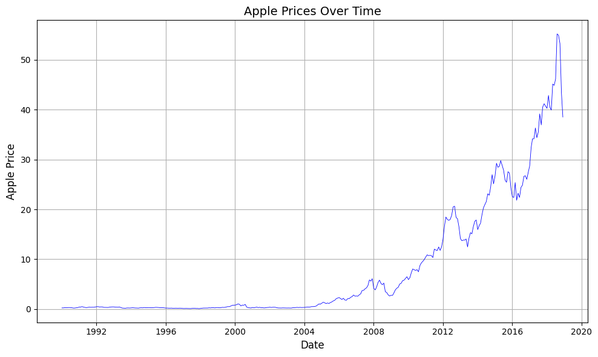

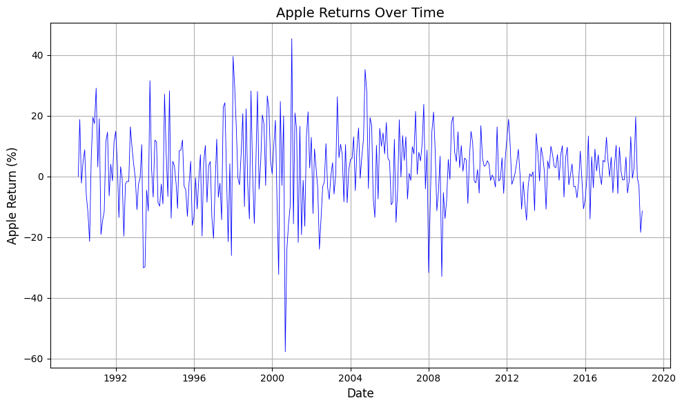

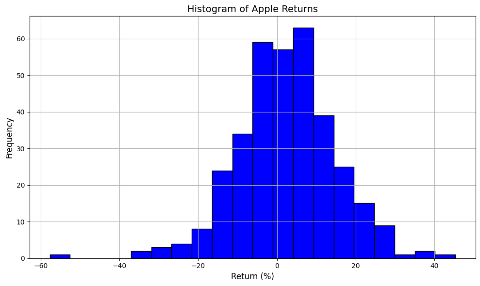

```python
# Import libraries
import pandas as pd
import numpy as np
import matplotlib.pyplot as plt
import seaborn as sns
from datetime import datetime

# Load data
# Replace with the actual path to your Excel file
file_path = "data/Return.xlsx"
df = pd.read_excel(file_path)
print(df.head())
df['Date'] = pd.to_datetime(df['date'])

# Plot Apple prices
plt.figure(figsize=(10, 6))
plt.plot(df['Date'], df['apple'], color='blue', linewidth=0.6)
plt.title("Apple Prices Over Time", fontsize=14)
plt.xlabel("Date", fontsize=12)
plt.ylabel("Apple Price", fontsize=12)
plt.xticks(fontsize=10)
plt.yticks(fontsize=10)
plt.grid(visible=False)
plt.tight_layout()
plt.grid()
plt.show()

# Calculate returns
df['Return'] = df['apple'].pct_change() * 100

# Plot Returns
plt.figure(figsize=(10, 6))
plt.plot(df['Date'], df['Return'], color='blue', linewidth=0.6)
plt.title("Apple Returns Over Time", fontsize=14)
plt.xlabel("Date", fontsize=12)
plt.ylabel("Apple Return (%)", fontsize=12)
plt.xticks(fontsize=10)
plt.yticks(fontsize=10)
plt.grid(visible=False)
plt.grid()
plt.tight_layout()
plt.show()

# Histogram of Returns
plt.figure(figsize=(10, 6))
plt.hist(df['Return'].dropna(), bins=20, color='blue', edgecolor='black')
plt.title("Histogram of Apple Returns", fontsize=14)
plt.xlabel("Return (%)", fontsize=12)
plt.ylabel("Frequency", fontsize=12)
plt.xticks(fontsize=10)
plt.yticks(fontsize=10)
plt.grid(visible=False)
plt.tight_layout()
plt.grid()
plt.show()
```

# The Theory of the CAPM

## Overview

The Capital Asset Pricing Model (CAPM) is a foundational concept in modern financial economics. It provides a framework for understanding the relationship between **expected returns** on risky assets and their associated **risk**, building on **mean-variance optimization**.

## Key Concepts

### Purpose of CAPM

- Predicts expected returns on risky assets.
- Helps evaluate investment opportunities.
- Provides a benchmark for equilibrium returns of stocks, even those not yet traded.

### Assumptions of CAPM

1. **Perfect Competition**:
   - Many small investors are price takers.
   - No single investor can influence market prices.
2. **Risk-Free Borrowing and Lending**:
   - Investors can lend or borrow at a risk-free rate without constraints.
3. **Single-Period Horizon**:
   - All investors plan over the same time horizon, simplifying calculations.
4. **Tradable Financial Assets Only**:
   - Only publicly traded assets are considered (e.g., bonds, stocks).
   - Non-tradable assets like private businesses or human capital are excluded.
5. **No Taxes or Transaction Costs**:
   - Simplifies investment decisions.
6. **Rational, Homogeneous Investors**:
   - Investors are rational and aim to maximize returns for a given level of risk.
   - Use the **Markowitz portfolio selection model** with shared expectations about securities.

## Conclusions Derived from CAPM

### 1. Market Portfolio Representation

- All investors hold a portfolio of risky assets that mirrors the **market portfolio (M)**, representing the total wealth in the economy.
- The **market portfolio** is composed of all traded assets weighted by their market values.

### 2. Efficient Frontier and the Capital Market Line (CML)

- The **CML** is the optimal Capital Allocation Line (CAL) with the highest **Sharpe ratio**.
- All investors hold the market portfolio $M$ combined with varying amounts of the risk-free asset.

### 3. Market Risk Premium

- The risk premium on the market portfolio is proportional to:
  - **Systematic risk** ($\sigma_M^2$).
  - **Average risk aversion** ($\bar{A}$): $$ E(r_M) - r_f = \bar{A} \cdot \sigma_M^2 $$

### 4. Risk Premium on Individual Assets

- The risk premium of an asset is proportional to its **beta ($\beta_i$)**: $$ E(r_i) - r_f = \beta_i \cdot [E(r_M) - r_f] $$
- **Beta ($\beta_i$)** measures the asset’s sensitivity to the market’s movements: $$ \beta_i = \frac{\text{Cov}(r_i, r_M)}{\sigma_M^2} $$

### 5. Expected Return-Beta Relationship

- The expected return on an asset is determined by its beta: $$ E(r_i) = r_f + \beta_i \cdot [E(r_M) - r_f] $$
- Riskier assets (higher beta) offer higher expected returns.

## Implications

1. **Market Portfolio is Optimal**:
   - All investors achieve optimal diversification by holding the market portfolio.
   - The market portfolio incorporates all relevant information about securities, making **passive investing** efficient.
2. **Market Price of Risk**:
   - The ratio of the market risk premium to market variance: $$ \text{Market Price of Risk} = \frac{E(r_M) - r_f}{\sigma_M^2} $$
3. **Portfolio Variance Contribution**:
   - Each asset contributes to portfolio variance based on its covariance with the market portfolio: $$ w_i \cdot \text{Cov}(r_i, r_M) $$
   - Assets with negative covariance can reduce overall portfolio risk.

## Practical Applications

1. **Investment Evaluation**:
   - CAPM provides a **benchmark rate of return** to assess whether an investment is attractive.
2. **Risk Management**:
   - Beta ($\beta$) helps investors understand and manage the systematic risk of individual securities.
3. **Passive vs. Active Management**:
   - CAPM supports the efficiency of **passive strategies** by emphasizing the market portfolio.

## Limitations of CAPM

1. **Simplifying Assumptions**:
   - Assumes no taxes, transaction costs, or constraints, which may not hold in real markets.
   - Assumes all investors share the same expectations and risk preferences.
2. **Beta’s Limitations**:
   - Beta only measures sensitivity to market movements, not other risks (e.g., firm-specific risks).
3. **Focus on Systematic Risk**:
   - Ignores unsystematic risks, which may still affect portfolio performance.

## Conclusion

The CAPM provides a theoretical foundation for understanding the relationship between risk and return. While its assumptions may not fully reflect real-world complexities, it remains a vital tool for financial analysis, investment decisions, and portfolio management.

# Notes on Interpreting the CAPM Model

## 1. Overview of CAPM Interpretation

- The **CAPM equation** relates the expected return of an asset to its risk in comparison to the market.
- The **risk premium** for an asset is explained by its **beta**, which measures how its excess return covaries with the market’s excess return.

## 2. CAPM Equation

The CAPM formula states:

$$ E(r_j) = r_{rf} + \beta_j \cdot \left( E(r_M) - r_{rf} \right) $$

Where:

- $ E(r_j) $: Expected return of the asset.
- $ r_{rf} $: Risk-free rate (e.g., 3-month Treasury bills).
- $ E(r_M) - r_{rf} $: Market risk premium.
- $ \beta_j $: Sensitivity of the asset’s return to the market.

## 3. Components of the Risk Premium

- **Alpha ($ \alpha_j $)**:
  - Measures whether the asset is in equilibrium.
  - **Positive Alpha ($ \alpha_j > 0 $)**: The asset pays more than expected given its risk.
  - **Negative Alpha ($ \alpha_j < 0 $)**: The asset pays less than expected given its risk.
- **Beta ($ \beta_j $)**:
  - Reflects the systematic risk of the asset relative to the market.
  - $ \beta_j > 1 $: Asset is riskier than the market.
  - $ \beta_j < 1 $: Asset is less risky than the market.
- **Epsilon ($ \epsilon_j $)**:
  - Captures random noise, measurement error, or omitted factors affecting the asset’s return.

## 4. Steps to Estimate CAPM Parameters

1. **Data Collection**:
   - Gather historical data for:
     - Asset returns ($ r_j $).
     - Market returns ($ r_M $).
     - Risk-free rate ($ r_{rf} $).
2. **Compute Excess Returns**:
   - Calculate excess returns:
     - $ r_j - r_{rf} $
     - $ r_M - r_{rf} $
3. **OLS Regression**:
   - Use the regression equation: $$ r_j - r_{rf} = \alpha_j + \beta_j \cdot (r_M - r_{rf}) + \epsilon_j $$
   - Alpha ($ \alpha_j $) is the constant term, and Beta ($ \beta_j $) is the slope.
4. **Evaluate Results**:
   - **Alpha**: Indicates disequilibrium if significantly different from zero.
   - **Beta**: Measures the risk level compared to the market.
   - **R-squared**: Reflects how well the model explains the variability in returns.

## 5. Example Interpretation

- **Alpha ($ \alpha_j $)**:
  - Example: $ \alpha_j = 1.226 $: The stock is in disequilibrium and pays more than expected given its systematic risk.
- **Beta ($ \beta_j $)**:
  - Example: $ \beta_j > 1 $: The stock is riskier than the market, meaning its returns fluctuate more with market movements.
- **R-squared**:
  - Example: $ R^2 = 0.191 $: The model explains 19.1% of the variability in the asset's excess return.

## 6. Insights from the CAPM

- The CAPM is a forward-looking model assuming that **current risk premiums** predict **future returns**.
- Adding **Alpha ($ \alpha_j $)** accounts for possible market inefficiencies or additional influences.
- Interpretation of the parameters helps determine whether an asset is priced fairly based on its risk.

## 7. Key Takeaways

- **CAPM’s Core Idea**:
  - The risk premium on any asset is proportional to the market risk premium, scaled by Beta.
- **Usefulness**:
  - Alpha helps identify undervalued or overvalued stocks.
  - Beta explains how much risk an asset adds to a portfolio.
- **Practical Estimation**:
  - Use historical data for the stock and market in regression models to estimate Alpha and Beta.

```
                            OLS Regression Results
==============================================================================
Dep. Variable:           excess_apple   R-squared:                       0.001
Model:                            OLS   Adj. R-squared:                 -0.002
Method:                 Least Squares   F-statistic:                    0.2373
Date:                Sun, 08 Dec 2024   Prob (F-statistic):              0.626
Time:                        14:02:09   Log-Likelihood:                -1364.5
No. Observations:                 348   AIC:                             2733.
Df Residuals:                     346   BIC:                             2741.
Df Model:                           1
Covariance Type:            nonrobust
=================================================================================
                    coef    std err          t      P>|t|      [0.025      0.975]
---------------------------------------------------------------------------------
const             7.6195      0.663     11.487      0.000       6.315       8.924
excess_market     0.0756      0.155      0.487      0.626      -0.230       0.381
==============================================================================
Omnibus:                      114.486   Durbin-Watson:                   0.009
Prob(Omnibus):                  0.000   Jarque-Bera (JB):              246.957
Skew:                           1.728   Prob(JB):                     2.37e-54
Kurtosis:                       5.255   Cond. No.                         4.33
==============================================================================

Notes:
[1] Standard Errors assume that the covariance matrix of the errors is correctly specified.
```

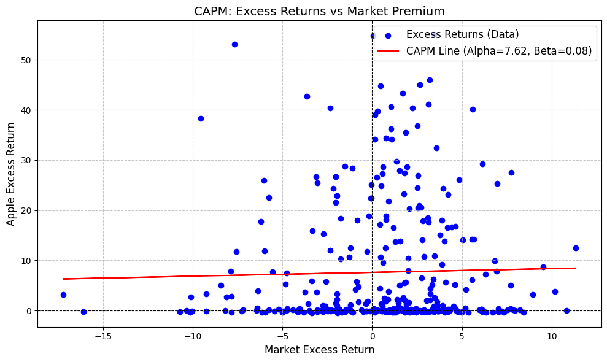

```python
import pandas as pd
import matplotlib.pyplot as plt
import statsmodels.api as sm

# Load the data
file_path = "data/Return.xlsx"
df = pd.read_excel(file_path)

# Convert 'date' column to datetime
df['date'] = pd.to_datetime(df['date'], format='%d-%m-%y')

# Calculate excess returns
df['excess_apple'] = df['apple'] - df['rf']
df['excess_market'] = df['mktrf']

# OLS regression: r_apple - r_rf = alpha + beta * (r_market - r_rf) + epsilon
X = sm.add_constant(df['excess_market'])  # Add constant for Alpha
y = df['excess_apple']
model = sm.OLS(y, X).fit()

# Print regression summary
print(model.summary())

# Extract Alpha and Beta
alpha = model.params['const']
beta = model.params['excess_market']

# Plot the data and regression line
plt.figure(figsize=(10, 6))
plt.scatter(df['excess_market'], df['excess_apple'], label="Excess Returns (Data)", color='blue')
plt.plot(df['excess_market'], alpha + beta * df['excess_market'], color='red', label=f"CAPM Line (Alpha={alpha:.2f}, Beta={beta:.2f})")
plt.axhline(0, color='black', linestyle='--', linewidth=0.8)
plt.axvline(0, color='black', linestyle='--', linewidth=0.8)
plt.title("CAPM: Excess Returns vs Market Premium", fontsize=14)
plt.xlabel("Market Excess Return", fontsize=12)
plt.ylabel("Apple Excess Return", fontsize=12)
plt.legend(fontsize=12)
plt.grid(True, linestyle='--', alpha=0.7)
plt.tight_layout()
plt.show()
```

# Interpretation of OLS Regression Results

# Ideal Behavior of OLS Regression Results

| **Metric** | **Description** | **Ideal Behavior** | **Explanation/Range** |
| --- | --- | --- | --- |
| **R-squared** | Proportion of variation explained by the model. | Higher is better | Values closer to 1 are ideal (e.g., > 0.6 for strong models). |
| **Adjusted R-squared** | R-squared adjusted for the number of predictors. | Higher is better | Should be close to R-squared but not higher; negative indicates issues. |
| **AIC (Akaike)** | Model fit and complexity metric. | Lower is better | Compare across models; no fixed range, but lower is preferred. |
| **BIC (Bayesian)** | Similar to AIC but penalizes more for additional predictors. | Lower is better | Compare across models; lower is preferred. |
| **F-statistic** | Tests overall significance of the model. | Higher is better | Significant if $ p < 0.05 $; high values indicate a meaningful model. |
| **Prob (F-statistic)** | P-value for the F-test. | Lower is better | Significant if $ p < 0.05 $. |
| **Log-Likelihood** | Indicates model likelihood given the data. | Higher is better | No fixed range; compare across models. |
| **Durbin-Watson** | Tests for autocorrelation in residuals. | Close to 2 | Values < 1 or > 3 suggest strong autocorrelation. |
| **Omnibus** | Tests for normality of residuals. | Lower is better | Significant if $ p > 0.05 $; high values indicate non-normal residuals. |
| **Prob (Omnibus)** | P-value for Omnibus test. | Higher is better | Significant if $ p > 0.05 $. |
| **Jarque-Bera (JB)** | Another test for normality of residuals. | Lower is better | Significant if $ p > 0.05 $. |
| **Prob (JB)** | P-value for Jarque-Bera test. | Higher is better | Significant if $ p > 0.05 $. |
| **Skew** | Symmetry of residuals. | Close to 0 | Negative values = left skew, positive = right skew. Ideal: -0.5 to 0.5. |
| **Kurtosis** | Tails of the residual distribution. | Close to 3 | Ideal: ~3; >3 = heavy tails, <3 = light tails. |
| **Condition Number** | Multicollinearity indicator. | Lower is better | <10 is good; >30 suggests multicollinearity issues. |

## **Regression Summary**

### **1. Dependent Variable: `excess_apple`**

- **Definition**: Apple’s excess return ($ r_{\text{apple}} - r_f $).
- **Interpretation**: It represents how Apple’s return compares to the risk-free rate.

### **2. R-squared: 0.001**

- **Meaning**: The model explains only **0.1%** of the variation in Apple’s excess return.
- **Implication**: The market excess return ($ r_{\text{market}} - r_f $) has almost no explanatory power for Apple’s excess return.

### **3. Adjusted R-squared: -0.002**

- **Meaning**: After adjusting for the number of predictors, the model explains less than **0%** of the variation.
- **Implication**: Adding more variables to this model might not improve its explanatory power unless they are strongly correlated with Apple’s excess returns.

### **4. F-statistic: 0.2373, Prob (F-statistic): 0.626**

- **F-statistic**: Tests whether the regression model (with the predictor $ r_{\text{market}} - r_f $) explains the variation in $ r_{\text{apple}} - r_f $.
- **P-value (Prob)**: 0.626 indicates the predictor is **not statistically significant**.
- **Implication**: The market excess return is not a meaningful factor in explaining Apple’s excess return.

### **5. Log-Likelihood: -1364.5**

- **Meaning**: A measure of the model's fit. Higher values indicate a better fit.
- **Implication**: The low value here reflects poor model fit.

### **6. AIC (Akaike Information Criterion): 2733.**

- **Meaning**: A metric for comparing models. Lower values are better.
- **Implication**: This value indicates poor fit relative to alternatives. A better model should reduce this value.

### **7. BIC (Bayesian Information Criterion): 2741.**

- **Meaning**: Similar to AIC but penalizes for the number of predictors more heavily.
- **Implication**: Like AIC, a lower BIC indicates a better model.

## **Coefficients and Their Interpretation**

### **1. Constant (`const`): 7.6195**

- **Meaning**: Alpha, or the average excess return of Apple when the market excess return is zero.
- **Significance**: Highly significant ($ p < 0.001 $).
- **Implication**: Apple has an average excess return of 7.62% independent of market movements, which might indicate its unique ability to generate returns beyond market factors.

### **2. Market Excess Return (`excess_market`): 0.0756**

- **Meaning**: Beta, or Apple’s sensitivity to market movements.
- **Interpretation**: For every 1% increase in market excess return, Apple’s excess return increases by only 0.0756%.
- **Significance**: Not statistically significant ($ p = 0.626 $).
- **Implication**: Apple’s returns are weakly correlated with the market’s performance, and market risk ($ r_{\text{market}} - r_f $) is not a major driver.

## **Standard Errors and Confidence Intervals**

### **1. Standard Error (`std err`)**

- **Constant**: $ \pm 0.663 $
  - Alpha’s precision is high, indicating confidence in the estimate.
- **Market Excess Return**: $ \pm 0.155 $
  - The high standard error relative to the coefficient shows that the Beta estimate is imprecise.

### **2. Confidence Interval**

- **Constant**: [6.315, 8.924]
  - We are 95% confident Alpha lies within this range.
- **Market Excess Return**: [-0.230, 0.381]
  - The interval crosses zero, reinforcing that Beta is not significant.

## **Residual Diagnostics**

### **1. Omnibus: 114.486, Prob (Omnibus): 0.000**

- **Meaning**: Tests whether residuals (errors) follow a normal distribution.
- **Implication**: Residuals are not normally distributed, suggesting potential issues with model assumptions.

### **2. Jarque-Bera (JB): 246.957, Prob (JB): 2.37e-54**

- **Meaning**: Confirms residuals are skewed and have heavy tails.
- **Implication**: The residuals do not behave as expected under the OLS assumptions.

### **3. Skew: 1.728**

- **Meaning**: The residuals are right-skewed.
- **Implication**: Indicates some systematic deviation in the data.

### **4. Kurtosis: 5.255**

- **Meaning**: The residuals have heavy tails compared to a normal distribution.
- **Implication**: Outliers might be affecting the model.

### **5. Durbin-Watson: 0.009**

- **Meaning**: Tests for autocorrelation in residuals. Values near 2 indicate no autocorrelation.
- **Implication**: Strong positive autocorrelation is present, suggesting the model is missing key patterns in the data.

## **Cond. No. (Condition Number): 4.33**

- **Meaning**: Measures potential multicollinearity or instability in the model.
- **Implication**: No major issues with multicollinearity in this simple model.

## **Overall Implications**

### **1. Model Fit**

- The market factor does not explain Apple’s excess returns ($ R^2 = 0.001 $).
- Alpha ($ 7.6195 $) suggests Apple consistently outperforms the risk-free rate, independent of market movements.

### **2. Limitations**

- Residuals do not follow a normal distribution, and autocorrelation is high.
- Additional factors like SMB, HML, or industry-specific variables might better explain Apple’s returns.

### **3. Conclusion**

- This model poorly captures the drivers of Apple’s returns, indicating the need for a more complex model or additional variables.

# Fama and French Three-Factor Model

## Overview

The **Fama and French Three-Factor Model** extends the **Capital Asset Pricing Model (CAPM)** by introducing two additional factors—**Size (SMB)** and **Value (HML)**—to better explain stock returns.

## Model Equation

- $ r_{j,t} - r_{rf,t} $: **Excess return** of an asset $ j $ (stock return minus risk-free rate).
- $ r_{m,t} - r_{rf,t} $: **Market excess return** (market return minus risk-free rate).
- $ SMB_t $: **Small Minus Big** (size factor)—difference in returns between small-cap and large-cap stocks.
- $ HML_t $: **High Minus Low** (value factor)—difference in returns between high book-to-market and low book-to-market stocks.
- $ \alpha_j $: Intercept (Jensen’s Alpha), measures abnormal returns.
- $ \beta_j, \gamma_j, \eta_j $: Sensitivity coefficients to market, size, and value factors.
- $ \epsilon_{j,t} $: Residual error (random noise).

## Factors Explained

### 1. **Market Risk (CAPM Factor)**

- The market excess return ($ r_{m,t} - r_{rf,t} $) captures the **systematic risk** shared by all assets.
- Assets with higher sensitivity to market movements ($ \beta_j $) have higher expected returns.

## Why Extend CAPM?

1. **Limitations of CAPM**:
   - CAPM only considers market risk ($ \beta_j $) and assumes it explains all variation in returns.
   - Empirical evidence shows size and value also influence returns.
2. **Improved Explanation of Returns**:
   - Adding SMB and HML factors increases the model’s ability to explain stock return variability.
3. **Empirical Basis**:
   - Extensive historical data demonstrates that size and value factors significantly affect returns.

## Practical Implications

### 1. **Portfolio Management**

- Investors can align portfolios with desired exposures to market, size, and value factors.

### 2. **Risk Decomposition**

- The model decomposes an asset’s returns into contributions from market risk, size risk, and value risk.

### 3. **Performance Analysis**

- Helps determine whether a portfolio's performance is due to systematic factors (market, size, value) or manager skill (Alpha).

## Comparison with CAPM

| **Aspect** | **CAPM** | **Fama and French** |
| --- | --- | --- |
| **Factors** | Market Risk | Market Risk, Size (SMB), Value (HML) |
| **Explanatory Power** | Limited | Greater (explains more variation in returns) |
| **Focus** | Broad Market Exposure | Adds size and value as drivers of returns |
| **Portfolio Insights** | Basic | Detailed factor-based insights |

## Deriving Fama and French Factors (SMB and HML)

### 1. **SMB (Small Minus Big)**

- Divide stocks into **Small (S)** and **Big (B)** categories based on **market capitalization** (median split).
- Within each category, calculate average returns for Small-Cap and Large-Cap portfolios.
- Compute SMB as: $$ SMB_t = \frac{1}{3} (R_{S/H} + R_{S/M} + R_{S/L}) - \frac{1}{3} (R_{B/H} + R_{B/M} + R_{B/L}) $$
  - $ R_{S/H} $: Return of small-cap, high book-to-market stocks.
  - $ R_{B/L} $: Return of large-cap, low book-to-market stocks.

### 2. **HML (High Minus Low)**

- Divide stocks into **High (H)**, **Medium (M)**, and **Low (L)** categories based on **book-to-market ratios** (tercile split).
- Compute HML as: $$ HML_t = \frac{1}{2} (R_{S/H} + R_{B/H}) - \frac{1}{2} (R_{S/L} + R_{B/L}) $$
  - $ R_{S/H} $: Return of small-cap, high book-to-market stocks.
  - $ R_{B/L} $: Return of large-cap, low book-to-market stocks.

## Conclusion

The **Fama and French Model** improves on CAPM by incorporating size and value factors, making it a robust tool for understanding stock returns and guiding investment decisions. SMB and HML are derived by categorizing stocks based on market capitalization and book-to-market ratios, respectively, to capture these additional dimensions of risk.

```
                            OLS Regression Results
==============================================================================
Dep. Variable:           excess_apple   R-squared:                       0.013
Model:                            OLS   Adj. R-squared:                  0.004
Method:                 Least Squares   F-statistic:                     1.460
Date:                Sun, 08 Dec 2024   Prob (F-statistic):              0.225
Time:                        15:25:31   Log-Likelihood:                -1362.5
No. Observations:                 348   AIC:                             2733.
Df Residuals:                     344   BIC:                             2748.
Df Model:                           3
Covariance Type:            nonrobust
=================================================================================
                    coef    std err          t      P>|t|      [0.025      0.975]
---------------------------------------------------------------------------------
const             7.7341      0.664     11.646      0.000       6.428       9.040
excess_market     0.0656      0.160      0.409      0.683      -0.250       0.381
smb              -0.2633      0.218     -1.208      0.228      -0.692       0.166
hml              -0.4362      0.232     -1.883      0.061      -0.892       0.020
==============================================================================
Omnibus:                      109.985   Durbin-Watson:                   0.028
Prob(Omnibus):                  0.000   Jarque-Bera (JB):              229.018
Skew:                           1.681   Prob(JB):                     1.86e-50
Kurtosis:                       5.118   Cond. No.                         4.56
==============================================================================

Notes:
[1] Standard Errors assume that the covariance matrix of the errors is correctly specified.
```

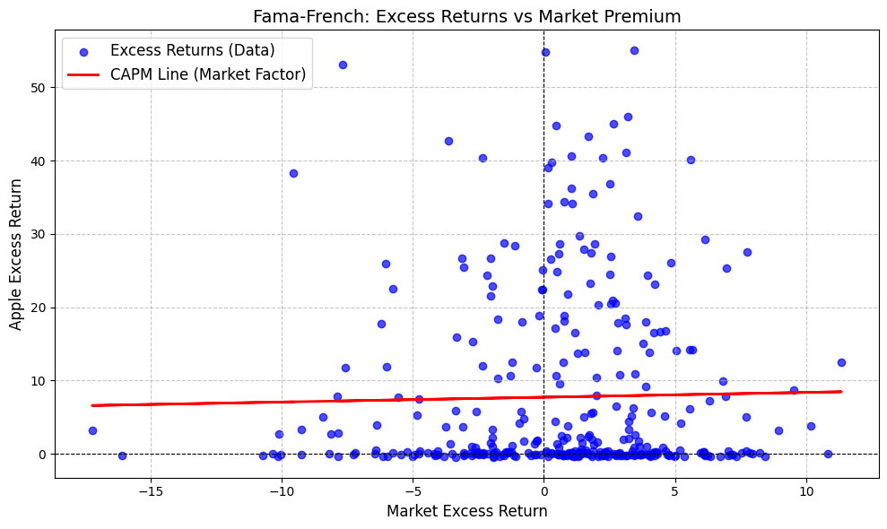

```python
# Add SMB and HML to the regression
X = df[['excess_market', 'smb', 'hml']]
X = sm.add_constant(X)  # Add constant for Alpha
y = df['excess_apple']

# Fit the extended Fama-French model
model = sm.OLS(y, X).fit()

# Print regression summary
print(model.summary())

# Extract coefficients
alpha = model.params['const']
beta_market = model.params['excess_market']
beta_smb = model.params['smb']
beta_hml = model.params['hml']

# Plot the relationship (excess_market vs excess_apple)
plt.figure(figsize=(10, 6))
plt.scatter(df['excess_market'], df['excess_apple'], color='blue', alpha=0.7, label="Excess Returns (Data)")
plt.plot(df['excess_market'], alpha + beta_market * df['excess_market'], color='red', label="CAPM Line (Market Factor)", linewidth=2)
plt.axhline(0, color='black', linestyle='--', linewidth=0.8)
plt.axvline(0, color='black', linestyle='--', linewidth=0.8)
plt.title("Fama-French: Excess Returns vs Market Premium", fontsize=14)
plt.xlabel("Market Excess Return", fontsize=12)
plt.ylabel("Apple Excess Return", fontsize=12)
plt.legend(fontsize=12)
plt.grid(True, linestyle='--', alpha=0.7)
plt.tight_layout()
plt.show()
```

```
                            OLS Regression Results
==============================================================================
Dep. Variable:         Excess_Returns   R-squared:                       0.191
Model:                            OLS   Adj. R-squared:                  0.189
Method:                 Least Squares   F-statistic:                     81.57
Date:                Sun, 08 Dec 2024   Prob (F-statistic):           1.22e-17
Time:                        15:38:45   Log-Likelihood:                -1335.0
No. Observations:                 347   AIC:                             2674.
Df Residuals:                     345   BIC:                             2682.
Df Model:                           1
Covariance Type:            nonrobust
==============================================================================
                 coef    std err          t      P>|t|      [0.025      0.975]
------------------------------------------------------------------------------
const          1.2263      0.618      1.985      0.048       0.012       2.441
mktrf          1.3089      0.145      9.032      0.000       1.024       1.594
==============================================================================
Omnibus:                       18.487   Durbin-Watson:                   1.913
Prob(Omnibus):                  0.000   Jarque-Bera (JB):               47.927
Skew:                          -0.137   Prob(JB):                     3.92e-11
Kurtosis:                       4.800   Cond. No.                         4.32
==============================================================================

Notes:
[1] Standard Errors assume that the covariance matrix of the errors is correctly specified.
```

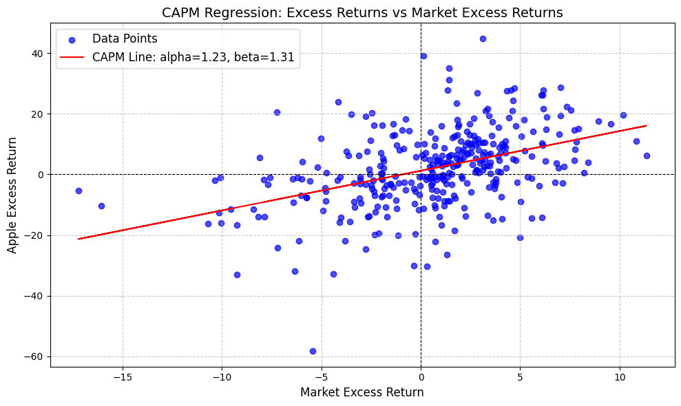

```python
import pandas as pd
import numpy as np
import statsmodels.api as sm
import matplotlib.pyplot as plt

# Load the data
file_path = "data/Return.xlsx"
df = pd.read_excel(file_path)

# Convert 'date' column to datetime
df['Date'] = pd.to_datetime(df['date'], format='%d-%m-%y')

# Calculate returns
df['Return'] = df['apple'].pct_change() * 100

# Build the variables for the regression: excess returns
df['Excess_Returns'] = df['Return'] - df['rf']
# 'mktrf' already represents excess market returns

# Regress the basic model (no robust SE)
X = sm.add_constant(df['mktrf'])  # Add a constant for the intercept (alpha)
y = df['Excess_Returns']

model_1 = sm.OLS(y, X, missing='drop').fit()  # Drop NaN values automatically

# Print regression results
print(model_1.summary())

# Extract coefficients
alpha = model_1.params['const']
beta = model_1.params['mktrf']

# Visualization of Excess Returns vs Market Excess Returns
plt.figure(figsize=(10, 6))
plt.scatter(df['mktrf'], df['Excess_Returns'], color='blue', alpha=0.7, label="Data Points")
plt.plot(df['mktrf'], alpha + beta * df['mktrf'], color='red', label=f"CAPM Line: alpha={alpha:.2f}, beta={beta:.2f}")
plt.axhline(0, color='black', linestyle='--', linewidth=0.8)
plt.axvline(0, color='black', linestyle='--', linewidth=0.8)
plt.title("CAPM Regression: Excess Returns vs Market Excess Returns", fontsize=14)
plt.xlabel("Market Excess Return", fontsize=12)
plt.ylabel("Apple Excess Return", fontsize=12)
plt.legend(fontsize=12)
plt.grid(True, linestyle='--', alpha=0.7)
plt.tight_layout()
plt.show()
```

# Analysis of the Results After Adding SMB and HML

The updated regression results introduce the Fama-French factors (SMB and HML) into the model. Below is a detailed explanation of the changes and implications.

## **Key Changes in Model Fit**

1. **R-squared: 0.013 (was 0.001)**
   - **Interpretation**: The model now explains 1.3% of the variation in Apple’s excess return, up from 0.1%.
   - **Implication**: Adding SMB and HML improves the model's ability to explain returns, but the improvement is modest.
2. **Adjusted R-squared: 0.004 (was -0.002)**
   - **Interpretation**: Adjusted $ R^2 $, which penalizes adding predictors, is now positive, indicating a slight improvement in model fit.
3. **F-statistic: 1.460, Prob (F-statistic): 0.225**
   - **Interpretation**: The p-value for the F-test (0.225) indicates the overall model is not statistically significant.
   - **Implication**: The three factors (Market, SMB, HML) do not collectively explain a significant portion of the variability in Apple’s returns.

## **Regression Coefficients**

### **1. Constant (Alpha): 7.7341**

- **Change**: Alpha slightly increased from 7.6195 to 7.7341.
- **Interpretation**: Apple’s average excess return, independent of market, size, and value factors, remains positive and statistically significant ($ p < 0.001 $).
- **Implication**: Apple’s excess return may stem from factors beyond those captured by SMB, HML, or market risk.

### **2. Market Excess Return (Beta): 0.0656**

- **Change**: Beta decreased from 0.0756 to 0.0656 and remains statistically insignificant ($ p = 0.683 $).
- **Interpretation**: Apple’s sensitivity to market movements is still negligible, indicating its returns are largely unaffected by the market excess return.

### **3. SMB (Size Factor): -0.2633**

- **Interpretation**: The negative coefficient suggests Apple behaves more like a large-cap stock, which tends to underperform small-cap stocks. However, this effect is not statistically significant ($ p = 0.228 $).

### **4. HML (Value Factor): -0.4362**

- **Interpretation**: The negative coefficient implies Apple behaves more like a growth stock, which tends to underperform value stocks. The result is marginally significant ($ p = 0.061 $), hinting that HML may have some explanatory power for Apple’s returns.

## **Residual Diagnostics**

1. **Omnibus (109.985), Prob (Omnibus): 0.000**
   - **Interpretation**: Residuals are not normally distributed, as indicated by the small p-value.
2. **Durbin-Watson: 0.028**
   - **Interpretation**: Strong positive autocorrelation in residuals, violating OLS assumptions.
3. **Skew (1.681), Kurtosis (5.118)**
   - **Interpretation**: Residuals are right-skewed and have heavy tails.

## **Implications**

### **1. Model Fit**

- Adding SMB and HML slightly improves the explanatory power of the model, as shown by the increase in $ R^2 $ and adjusted $ R^2 $.
- However, the overall model is still weak, with a low $ R^2 $ and an insignificant F-test.

### **2. Alpha**

- Alpha remains significant, indicating that Apple generates abnormal returns beyond what the model can explain.

### **3. Market Factor (Beta)**

- Beta’s insignificance confirms that Apple’s returns are not strongly influenced by market movements.

### **4. Size and Value Factors**

- The marginal significance of HML ($ p = 0.061 $) suggests that Apple’s returns align more with growth stock behavior.
- The size factor (SMB) is not significant, reinforcing Apple’s large-cap characteristics.

### **5. Limitations**

- The presence of autocorrelation and non-normal residuals indicates potential issues with the model’s assumptions, suggesting the need for alternative approaches or additional variables.

## **Conclusion**

While adding SMB and HML provides some additional insight (particularly regarding Apple’s alignment with growth stocks), the overall model fit remains poor. Alpha’s significance suggests unexplained factors influencing Apple’s returns, and residual diagnostics indicate the model's limitations in capturing the data's full complexity.

# Changing the samples

```
                            OLS Regression Results
==============================================================================
Dep. Variable:         Excess_Returns   R-squared:                       0.251
Model:                            OLS   Adj. R-squared:                  0.244
Method:                 Least Squares   F-statistic:                     38.29
Date:                Sun, 08 Dec 2024   Prob (F-statistic):           2.28e-21
Time:                        16:13:44   Log-Likelihood:                -1321.7
No. Observations:                 347   AIC:                             2651.
Df Residuals:                     343   BIC:                             2667.
Df Model:                           3
Covariance Type:            nonrobust
==============================================================================
                 coef    std err          t      P>|t|      [0.025      0.975]
------------------------------------------------------------------------------
const          1.4742      0.599      2.462      0.014       0.297       2.652
mktrf          1.1359      0.145      7.837      0.000       0.851       1.421
smb            0.3077      0.196      1.569      0.117      -0.078       0.693
hml           -0.9279      0.208     -4.453      0.000      -1.338      -0.518
==============================================================================
Omnibus:                       11.726   Durbin-Watson:                   1.897
Prob(Omnibus):                  0.003   Jarque-Bera (JB):               24.210
Skew:                          -0.013   Prob(JB):                     5.53e-06
Kurtosis:                       4.294   Cond. No.                         4.55
==============================================================================

Notes:
[1] Standard Errors assume that the covariance matrix of the errors is correctly specified.
Alpha (const): 1.4742
Beta (Market): 1.1359
Beta (Size): 0.3077
Beta (Value): -0.9279
```

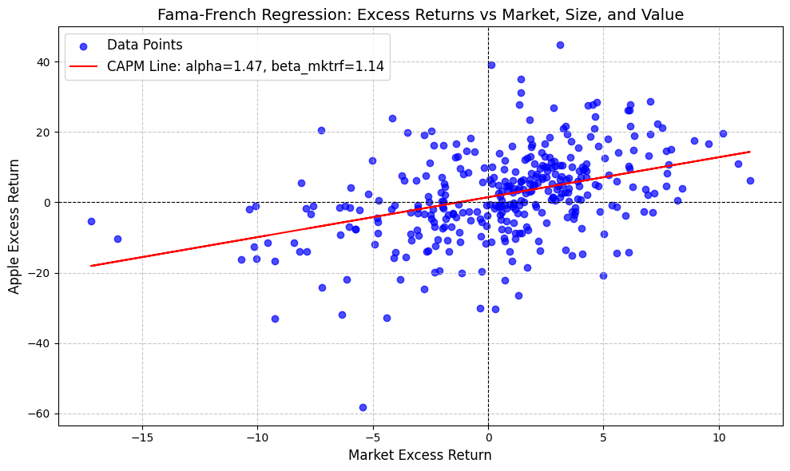

```python
import pandas as pd
import numpy as np
import statsmodels.api as sm
import matplotlib.pyplot as plt

# Load the data
file_path = "data/Return_changed.xlsx"
df = pd.read_excel(file_path)

# Convert 'date' column to datetime
df['Date'] = pd.to_datetime(df['date'], format='%Y%m%d')

# Calculate returns
df['Return'] = df['apple'].pct_change() * 100  # Percentage change in Apple's price

# Build the variables for the regression: excess returns
df['Excess_Returns'] = df['Return'] - df['rf']  # Apple's excess returns

# Prepare the independent variables for regression
X = df[['mktrf', 'smb', 'hml']]  # Market, size, and value factors
X = sm.add_constant(X)  # Add a constant for Alpha (intercept)
y = df['Excess_Returns']  # Apple's excess returns (dependent variable)

# Perform OLS regression
model = sm.OLS(y, X, missing='drop').fit()  # Drop NaN values automatically

# Print regression summary
print(model.summary())

# Extract coefficients
alpha = model.params['const']
beta_mktrf = model.params['mktrf']
beta_smb = model.params['smb']
beta_hml = model.params['hml']

# Print coefficients
print(f"Alpha (const): {alpha:.4f}")
print(f"Beta (Market): {beta_mktrf:.4f}")
print(f"Beta (Size): {beta_smb:.4f}")
print(f"Beta (Value): {beta_hml:.4f}")

# Visualization of Excess Returns vs Market Excess Returns
plt.figure(figsize=(10, 6))
plt.scatter(df['mktrf'], df['Excess_Returns'], color='blue', alpha=0.7, label="Data Points")
plt.plot(df['mktrf'], alpha + beta_mktrf * df['mktrf'], color='red', label=f"CAPM Line: alpha={alpha:.2f}, beta_mktrf={beta_mktrf:.2f}")
plt.axhline(0, color='black', linestyle='--', linewidth=0.8)
plt.axvline(0, color='black', linestyle='--', linewidth=0.8)
plt.title("Fama-French Regression: Excess Returns vs Market, Size, and Value", fontsize=14)
plt.xlabel("Market Excess Return", fontsize=12)
plt.ylabel("Apple Excess Return", fontsize=12)
plt.legend(fontsize=12)
plt.grid(True, linestyle='--', alpha=0.7)
plt.tight_layout()
plt.show()
```

# The Markowitz Model (Modern Portfolio Theory)

## Overview

The **Markowitz Model**, also known as **Modern Portfolio Theory (MPT)**, is a framework for constructing an optimal portfolio by balancing **risk** and **return**. It helps investors choose the best combination of investments to achieve the highest return for a given level of risk.

## Goals of the Model

- **Maximize Return**: Ensure the highest possible return for a specific level of risk.
- **Minimize Risk**: Reduce uncertainty for a given level of return through diversification.

## Key Concepts

### 1. **Expected Return**

The **expected return** of a portfolio is the weighted average of the expected returns of individual investments:

$$ E(R_p) = \sum_{i=1}^{n} w_i \cdot E(R_i) $$

Where:

- $E(R_p)$: Expected return of the portfolio.
- $w_i$: Proportion of money invested in asset $i$.
- $E(R_i)$: Expected return of asset $i$.

### 2. **Portfolio Risk**

The **risk** of a portfolio depends not only on the risk of individual assets but also on how they move relative to each other (**correlation**). The portfolio variance is given by:

$$ \sigma_p^2 = \sum_{i=1}^n \sum_{j=1}^n w_i w_j \cdot \text{Cov}(R_i, R_j) $$

Where:

- $\sigma_p^2$: Variance of the portfolio (measure of risk).
- $w_i, w_j$: Proportions invested in assets $i$ and $j$.
- $\text{Cov}(R_i, R_j)$: Covariance between the returns of assets $i$ and $j$.

### 3. **Correlation**

- **Positive Correlation**: Investments move in the same direction.
- **Negative Correlation**: Investments move in opposite directions.
- Diversification works best when investments have **low or negative correlation**, reducing overall risk.

## Efficient Frontier

The **Efficient Frontier** is a curve showing the best possible portfolios for a given level of risk. Portfolios on the Efficient Frontier:

- Provide the **highest return for a given level of risk**.
- Are the most efficient portfolios available.

Portfolios below the Efficient Frontier are **inefficient** because better options exist.

## Capital Allocation Line (CAL)

When a **risk-free asset** is introduced (like a government bond), you can combine it with portfolios on the Efficient Frontier to create the **Capital Allocation Line (CAL)**.

- The CAL shows the best possible combinations of the risk-free asset and a risky portfolio.
- The slope of the CAL is the **Sharpe Ratio**:

$$ \text{Sharpe Ratio} = \frac{E(R_p) - R_f}{\sigma_p} $$

Where:

- $E(R_p)$: Expected return of the portfolio.
- $R_f$: Risk-free rate.
- $\sigma_p$: Portfolio risk (standard deviation).

## Practical Steps in the Markowitz Model

1. **List Investments**: Identify possible assets and their expected returns, risks, and correlations.
2. **Calculate Risk and Return**: Determine the expected return and variance for different portfolio combinations.
3. **Find the Efficient Frontier**: Identify portfolios that maximize return for a given level of risk.
4. **Combine with Risk-Free Asset**: Use the CAL to decide how much to invest in the risk-free asset and the risky portfolio.

## Key Insights

### 1. **Diversification**

- **"Don’t put all your eggs in one basket."**
- By combining different assets, you can reduce risk without reducing returns.

### 2. **Efficient Portfolios**

- Efficient portfolios lie on the Efficient Frontier and offer the best tradeoff between risk and return.

### 3. **Sharpe Ratio**

- The Sharpe Ratio helps identify portfolios that maximize returns for each unit of risk.

## Connection to CAPM

- The Markowitz Model forms the basis for the **Capital Asset Pricing Model (CAPM)**.
- CAPM assumes all investors use the Markowitz Model and hold the **market portfolio**, which lies on the Efficient Frontier.

# Peer-graded Assignment

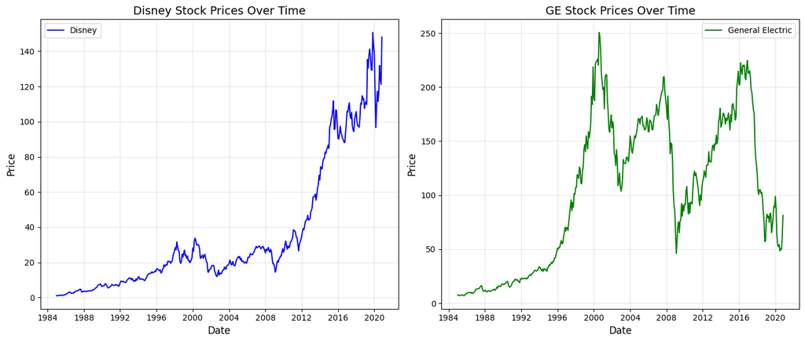

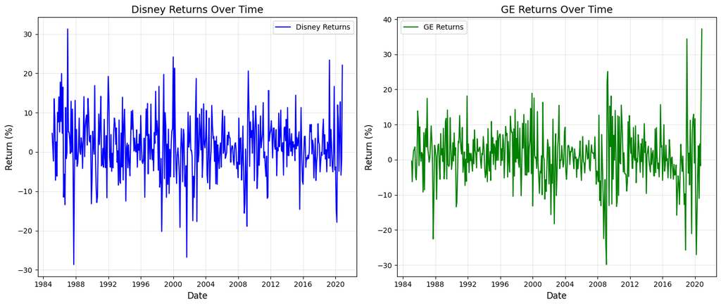

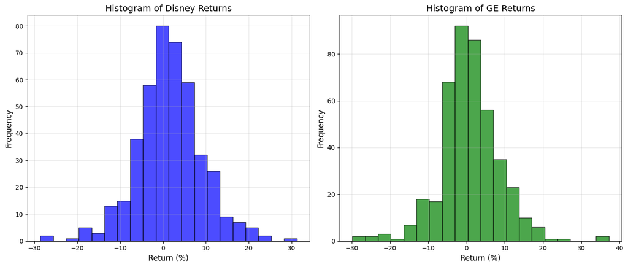

```
Disney CAPM Model:
                             OLS Regression Results
==============================================================================
Dep. Variable:          Excess_Return   R-squared:                       0.445
Model:                            OLS   Adj. R-squared:                  0.444
Method:                 Least Squares   F-statistic:                     343.3
Date:                Sun, 08 Dec 2024   Prob (F-statistic):           1.04e-56
Time:                        16:39:27   Log-Likelihood:                -1358.9
No. Observations:                 430   AIC:                             2722.
Df Residuals:                     428   BIC:                             2730.
Df Model:                           1
Covariance Type:            nonrobust
=================================================================================
                    coef    std err          t      P>|t|      [0.025      0.975]
---------------------------------------------------------------------------------
const             0.6454      0.277      2.328      0.020       0.100       1.190
Excess_Market     1.1368      0.061     18.529      0.000       1.016       1.257
==============================================================================
Omnibus:                       50.802   Durbin-Watson:                   2.137
Prob(Omnibus):                  0.000   Jarque-Bera (JB):              120.540
Skew:                           0.611   Prob(JB):                     6.69e-27
Kurtosis:                       5.288   Cond. No.                         4.55
==============================================================================

Notes:
[1] Standard Errors assume that the covariance matrix of the errors is correctly specified.

General Electric CAPM Model:
                             OLS Regression Results
==============================================================================
Dep. Variable:          Excess_Return   R-squared:                       0.432
Model:                            OLS   Adj. R-squared:                  0.431
Method:                 Least Squares   F-statistic:                     325.4
Date:                Sun, 08 Dec 2024   Prob (F-statistic):           1.61e-54
Time:                        16:39:27   Log-Likelihood:                -1375.6
No. Observations:                 430   AIC:                             2755.
Df Residuals:                     428   BIC:                             2763.
Df Model:                           1
Covariance Type:            nonrobust
=================================================================================
```

[output cut: 60 more lines]

```
smb              -0.2497      0.096     -2.600      0.010      -0.439      -0.061
hml               0.3781      0.097      3.894      0.000       0.187       0.569
==============================================================================
Omnibus:                       55.198   Durbin-Watson:                   1.798
Prob(Omnibus):                  0.000   Jarque-Bera (JB):              395.533
Skew:                          -0.201   Prob(JB):                     1.29e-86
Kurtosis:                       7.681   Cond. No.                         4.71
==============================================================================

Notes:
[1] Standard Errors assume that the covariance matrix of the errors is correctly specified.

Comparing CAPM and Fama-French Models:
Disney CAPM R-squared: 0.4451, Fama-French R-squared: 0.4521
GE CAPM R-squared: 0.4319, Fama-French R-squared: 0.4657
```

```python
import pandas as pd
import numpy as np
import matplotlib.pyplot as plt
import statsmodels.api as sm

# Load data
disney_data = pd.read_excel("data/Disney Data.xlsx")
ge_data = pd.read_excel("data/General Electric Data.xlsx")

# Convert 'date' column to datetime
disney_data['Date'] = pd.to_datetime(disney_data['date'])
ge_data['Date'] = pd.to_datetime(ge_data['date'])

# Plot stock prices against time (side-by-side)
fig, axes = plt.subplots(1, 2, figsize=(14, 6))
axes[0].plot(disney_data['Date'], disney_data['disney'], color='blue', label='Disney')
axes[0].set_title("Disney Stock Prices Over Time", fontsize=14)
axes[0].set_xlabel("Date", fontsize=12)
axes[0].set_ylabel("Price", fontsize=12)
axes[0].grid(alpha=0.3)
axes[0].legend()

axes[1].plot(ge_data['Date'], ge_data['ge'], color='green', label='General Electric')
axes[1].set_title("GE Stock Prices Over Time", fontsize=14)
axes[1].set_xlabel("Date", fontsize=12)
axes[1].set_ylabel("Price", fontsize=12)
axes[1].grid(alpha=0.3)
axes[1].legend()

plt.tight_layout()
plt.show()

# Calculate returns
disney_data['Return'] = disney_data['disney'].pct_change() * 100
ge_data['Return'] = ge_data['ge'].pct_change() * 100

# Plot returns (side-by-side)
fig, axes = plt.subplots(1, 2, figsize=(14, 6))
axes[0].plot(disney_data['Date'], disney_data['Return'], color='blue', label='Disney Returns')
axes[0].set_title("Disney Returns Over Time", fontsize=14)
axes[0].set_xlabel("Date", fontsize=12)
axes[0].set_ylabel("Return (%)", fontsize=12)
axes[0].grid(alpha=0.3)
axes[0].legend()

axes[1].plot(ge_data['Date'], ge_data['Return'], color='green', label='GE Returns')
axes[1].set_title("GE Returns Over Time", fontsize=14)
axes[1].set_xlabel("Date", fontsize=12)
axes[1].set_ylabel("Return (%)", fontsize=12)
axes[1].grid(alpha=0.3)
axes[1].legend()

plt.tight_layout()
plt.show()

# Histogram of returns (side-by-side)
fig, axes = plt.subplots(1, 2, figsize=(14, 6))
axes[0].hist(disney_data['Return'].dropna(), bins=20, color='blue', alpha=0.7, edgecolor='black')
axes[0].set_title("Histogram of Disney Returns", fontsize=14)
axes[0].set_xlabel("Return (%)", fontsize=12)
axes[0].set_ylabel("Frequency", fontsize=12)
axes[0].grid(alpha=0.3)

axes[1].hist(ge_data['Return'].dropna(), bins=20, color='green', alpha=0.7, edgecolor='black')
axes[1].set_title("Histogram of GE Returns", fontsize=14)
axes[1].set_xlabel("Return (%)", fontsize=12)
axes[1].set_ylabel("Frequency", fontsize=12)
axes[1].grid(alpha=0.3)

plt.tight_layout()
plt.show()

# CAPM Model (Disney)
disney_data['Excess_Return'] = disney_data['Return'] - disney_data['rf']
disney_data['Excess_Market'] = disney_data['mktrf'] - disney_data['rf']
X_disney_capm = sm.add_constant(disney_data['Excess_Market'])
y_disney_capm = disney_data['Excess_Return']
capm_disney = sm.OLS(y_disney_capm, X_disney_capm, missing='drop').fit()

# CAPM Model (GE)
ge_data['Excess_Return'] = ge_data['Return'] - ge_data['rf']
ge_data['Excess_Market'] = ge_data['mktrf'] - ge_data['rf']
X_ge_capm = sm.add_constant(ge_data['Excess_Market'])
y_ge_capm = ge_data['Excess_Return']
capm_ge = sm.OLS(y_ge_capm, X_ge_capm, missing='drop').fit()

# Fama-French Model (Disney)
X_disney_ff = disney_data[['Excess_Market', 'smb', 'hml']]
X_disney_ff = sm.add_constant(X_disney_ff)
ff_disney = sm.OLS(y_disney_capm, X_disney_ff, missing='drop').fit()

# Fama-French Model (GE)
X_ge_ff = ge_data[['Excess_Market', 'smb', 'hml']]
X_ge_ff = sm.add_constant(X_ge_ff)
ff_ge = sm.OLS(y_ge_capm, X_ge_ff, missing='drop').fit()

# Print regression summaries
print("Disney CAPM Model:\n", capm_disney.summary())
print("\nGeneral Electric CAPM Model:\n", capm_ge.summary())
print("\nDisney Fama-French Model:\n", ff_disney.summary())
print("\nGeneral Electric Fama-French Model:\n", ff_ge.summary())

# Compare the models
print("\nComparing CAPM and Fama-French Models:")
print(f"Disney CAPM R-squared: {capm_disney.rsquared:.4f}, Fama-French R-squared: {ff_disney.rsquared:.4f}")
print(f"GE CAPM R-squared: {capm_ge.rsquared:.4f}, Fama-French R-squared: {ff_ge.rsquared:.4f}")
```

# Comparison and Contrast of Results from the Four Models

## Key Metrics and Comparison Table

| **Metric** | **Disney CAPM** | **Disney Fama-French** | **GE CAPM** | **GE Fama-French** |
| --- | --- | --- | --- | --- |
| **R-squared ($ R^2 $)** | 0.445 | 0.452 | 0.432 | 0.466 |
| **Adjusted $ R^2 $** | 0.444 | 0.448 | 0.431 | 0.462 |
| **Alpha (const)** | 0.6454 (**Significant**) | 0.6143 (**Significant**) | 0.0594 (**Not Sig.**) | -0.0067 (**Not Sig.**) |
| **Beta (Excess Market)** | 1.1368 (**Aggressive**) | 1.1702 (**Aggressive**) | 1.1506 (**Aggressive**) | 1.2322 (**Very Aggressive**) |
| **SMB Coefficient** | - | -0.0790 (**Not Sig.**) | - | -0.2497 (**Significant**) |
| **HML Coefficient** | - | 0.1886 (**Significant**) | - | 0.3781 (**Highly Sig.**) |
| **F-statistic** | 343.3 (**Strong Fit**) | 117.2 (**Improved Fit**) | 325.4 (**Strong Fit**) | 123.8 (**Improved Fit**) |
| **AIC (Model Fit)** | 2722 | 2720 | 2755 | 2733 |
| **BIC (Model Fit)** | 2730 | 2737 | 2763 | 2749 |

## Key Observations and Implications

### **1. Model Fit ($ R^2 $ and Adjusted $ R^2 $)**

- **Disney**:
  - CAPM explains **44.5%** of the variability in Disney’s excess returns, while Fama-French improves slightly to **45.2%**.
  - Adjusted $ R^2 $ remains consistent, showing that the added factors (SMB and HML) only marginally improve explanatory power.
- **General Electric**:
  - CAPM explains **43.2%**, while Fama-French improves more significantly to **46.6%**.
  - Adjusted $ R^2 $ indicates that SMB and HML play a more substantial role in GE’s return dynamics compared to Disney.

**Implication**:

- GE is better explained by the Fama-French model due to the relevance of SMB and HML factors.
- Disney’s returns are predominantly driven by market returns, with less impact from size or value effects.

### **2. Aggressiveness (Beta)**

**Implication**:

- GE is riskier than Disney, with higher potential returns in bull markets but more significant losses in bear markets.
- Disney offers a balance between moderate risk and return.

### **3. Alpha (Excess Return Above Market)**

- **Disney**:
  - Positive and significant Alpha ($ 0.6454 $ in CAPM, $ 0.6143 $ in Fama-French) suggests Disney generates consistent excess returns over the market.
- **General Electric**:
  - Insignificant Alpha ($ 0.0594 $ in CAPM, $-0.0067$ in Fama-French) indicates GE does not provide consistent returns above the market.

**Implication**:

- Disney is more attractive for long-term investors looking for consistent outperformance.
- GE’s performance is tied closely to market conditions and lacks a strong independent return.

### **4. SMB (Size Factor)**

- **Disney**:
  - SMB coefficient ($-0.0790$, not significant) suggests Disney’s returns are not strongly affected by size effects.
- **General Electric**:
  - SMB coefficient ($-0.2497$, significant) indicates GE behaves more like a **large-cap stock**, benefiting less from small-cap premiums.

**Implication**:

- GE’s returns align with large-cap behavior, while Disney’s size factor is negligible.

### **5. HML (Value Factor)**

- **Disney**:
  - HML coefficient ($0.1886$, significant) suggests Disney benefits slightly from **value stocks**.
- **General Electric**:
  - HML coefficient ($0.3781$, highly significant) indicates GE has a **stronger tilt towards value stocks**.

**Implication**:

- GE is more reliant on value-driven performance compared to Disney, which has a moderate reliance.

### **6. Model Comparison (CAPM vs. Fama-French)**

- **Disney**:
  - $ R^2 $ improvement is minimal from CAPM ($ 0.445 $) to Fama-French ($ 0.452 $).
  - SMB and HML add little explanatory power, showing Disney’s returns are mainly driven by market movements.
- **General Electric**:
  - $ R^2 $ improvement is significant from CAPM ($ 0.432 $) to Fama-French ($ 0.466 $).
  - SMB and HML factors are crucial for explaining GE’s returns, highlighting its sensitivity to size and value effects.

## Summary

### **Stock Classification**

- **Disney**: **Moderately Aggressive**
  - Slightly above-market volatility (Beta > 1) with consistent positive Alpha, indicating potential for stable excess returns.
  - Size and value factors play minimal roles.
- **General Electric**: **Highly Aggressive**
  - Higher market sensitivity (Beta > 1.2) with insignificant Alpha, indicating high risk and no consistent excess returns.
  - Strong dependence on size (negative SMB) and value (positive HML) factors.

### **Investment Recommendation**

- **Risk-Averse Investors**: Choose **Disney** for its balanced risk-return profile, positive Alpha, and moderate market sensitivity.
- **Risk-Tolerant Investors**: Consider **General Electric** for potentially higher returns driven by value stock exposure but with greater market sensitivity and risk.

### **Best Strategy**

- A diversified portfolio with both stocks can balance risks (Disney’s stability vs. GE’s aggressiveness) and capitalize on market opportunities.

# Conclusion